# 2022年巴菲特致股东的信

2023年2月25日

沃伦-巴菲特

董事会主席

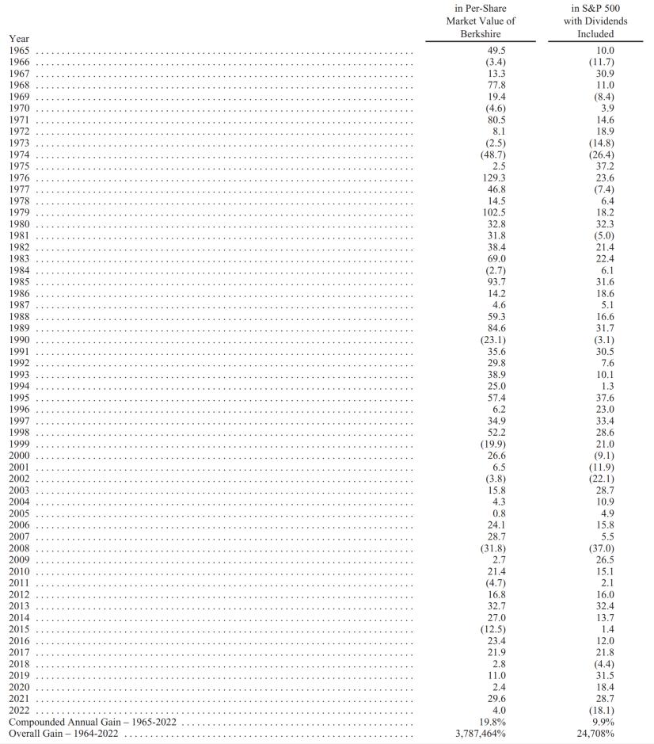

致伯克希尔哈撒韦公司股东：

查理·芒格，我的长期合作伙伴，我们的工作是管理很多人的储蓄。我们感谢他们持久的信任，这种关系往往贯穿他们成年后的大部分时间。在我写这封信的时候，我首先想到的就是那些热心的储蓄者。

一种普遍的看法是，人们选择在年轻时存钱，希望以此来维持退休后的生活水平。这一理论认为，死者死后留下的任何资产通常会留给家人，也有可能留给朋友和慈善机构。

我们的经历有所不同。我们认为，伯克希尔的个人股东基本上属于“一次储蓄，永远储蓄”的类型。虽然这些人生活得很好，但他们最终会把大部分资金捐给慈善机构。反过来，这些资金又通过旨在改善与原来的捐助者无关的许多人的生活的支出进行重新分配。有时，结果是惊人的。

金钱的处置揭示了人的本性。查理和我高兴地看到伯克希尔产生的大量资金流向公共需求，同时，我们的股东很少选择炫耀资产和王朝建设。

谁不喜欢为我们这样的股东工作呢？

**我们做什么**

查理和我把你在伯克希尔的存款分配给两种相关的所有权形式。首先，我们投资于我们控制的企业，通常是100%的收购。伯克希尔对这些子公司进行资本配置，并挑选出负责日常运营决策的首席执行官。在管理大型企业时，信任和规则都是必不可少的。伯克希尔对前者的强调达到了一种不同寻常的——有些人会说是极端的程度。失望在所难免。我们理解商业错误；我们对个人不端行为的容忍度为零。

在我们的第二类所有权中，我们购买公开交易的股票，通过这些股票我们被动地拥有企业的一部分。持有这些投资，我们在管理上没有发言权。

我们持有股权的目的都是，对具有长期良好经济特征和值得信赖的管理者的企业进行有意义的投资。请特别注意，我们持有公开交易的股票是基于我们对其长期经营业绩的预期，并不是因为我们把它们看作是短期买卖的工具。这一点很关键；查理和我选择的不是股票，我们选择的是公司。

这些年来，我犯了很多错误。因此，我们当前广泛投资的企业包括少数真正具有非凡经济效益的企业，许多企业享有非常好的经济特征，还有一大群企业处于边缘地位。在此过程中，我投资的一些企业已经倒闭，它们的产品不受公众欢迎。资本主义有两面性：这一体系创造了越来越多的输家，但同时提供了大量改进的商品和服务。熊彼特称这种现象为“创造性破坏”。

公开交易市场的一个优势是，偶尔可以很容易地以极好的价格买进一些极好的企业。重要的是要明白，股票交易的价格往往非常离谱，有可能是高得离谱，也有可能是低得离谱。“有效”市场只存在于教科书中。事实上，市场上的股票和债券价格常常令人困惑，投资者的行为通常只有在时过境迁后才能理解。

受控企业是另一种类型。它们的价格有时高得离谱，但几乎从来没有便宜的估值。除非受到胁迫，控股企业的所有者不会考虑以恐慌性估值出售。

* * * * * * * * * * * *

现在来看，我的成绩单是合格的；在伯克希尔58年的运营中，我的大部分资本配置决策都不怎么样。在某些情况下，我的一些坏棋被大量的运气挽救了。（还记得我们从美国航空公司（USAir）和所罗门公司（Salomon）的近乎灾难中逃生吗？我确实逃脱了。）

我们令人满意的业绩来自于十几个真正正确的决策——大约每五年一个——以及一个有时被人淡忘的优势，这个优势有利于伯克希尔这样的长期投资者。让我们看一看幕后。

**秘密武器**

1994年8月，是的，1994年。伯克希尔完成了对我们现在持有的4亿股可口可乐收购，先后花了7年时间，总成本为13亿美元。这在当时对伯克希尔来说是一笔非常大的数目。

1994年我们从可口可乐公司获得的现金分红是7500万美元。到2022年，股息增加到7.04亿美元。成长每年都在发生，就像生日一样确定无疑。查理和我只需要兑现可口可乐的季度股息支票。我们预计分红很可能会继续增加。

美国运通（American express）的情况大致相同。伯克希尔对美国运通的收购基本上是在1995年完成的，巧合的是，它也耗资13亿美元。这项投资的年度股息从4100万美元增加到3.02亿美元。这些数字似乎极有可能增加。

这些股息收益虽然令人满意，但远非壮观。但它们带来了股价的重要收益。截至年底，我们的可口可乐投资价值为250亿美元，而美国运通的投资价值为220亿美元。现在，这两个持股分别约占伯克希尔净资产的5%，类似于很久以前的权重。

假设一下：如果我在1990年代犯了一个类似规模的投资错误，这个错误导致投资价值持平、并在2022年简单维持在13亿美元价值的错误。（这方面的一个例子是买了30年期长期债券。）那么这项令人失望的投资，现在只占伯克希尔净资产的0.3%，并将为我们每年固定提供8000万美元左右的年收入。

给投资者的教训是：繁花绚烂盛开，蓬蒿默然枯萎。随着时间的推移，只需要几个赢家就能创造奇迹。而且，是的，尽早开始并活到90多岁也是很有帮助的。

**过去一年的简介**

伯克希尔在2022年度过了美好的一年。公司的营业利润——我们使用通用会计原则（“GAAP”）计算的收入术语，不包括股权持有的资本收益或损失——达到了创纪录的308亿美元。查理和我专注于这个运营数据，并敦促你也这样做。GAAP数据，如果没有我们的调整，在每个报告日都会剧烈而反复无常地波动。请注意它在2022年那杂耍一般的表现，这绝不罕见：

2022年季度 运营盈利 我们需要按照公认会计准则报告的收益

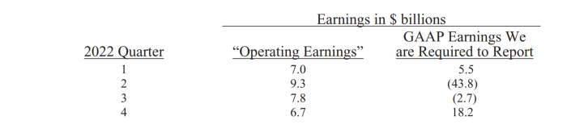

当按季度甚至按照年度业绩查看时，GAAP收益具有100%的误导性。可以肯定的是，在过去的几十年里，资本收益对伯克希尔来说非常重要，我们预计它们在未来几十年将产生有意义的积极价值。但是，它们季度的波动，经常被媒体盲目地报道，完全误导了投资者。

伯克希尔在过去一年的第二项积极进展是收购了Alleghany保险，这是一家由乔·布兰登（Joe Brandon）领导的财产-意外保险公司。我之前与乔共事过，他对伯克希尔和保险业都有独到见解。Allegany为我们带来了独特的价值，因为伯克希尔雄厚的财力能让保险子公司追求持久且有价值的投资战略，这是几乎所有竞争对手都无法企及的。

在Alleghany的帮助下，我们的保险浮存金在2022年从1470亿美元增加到1640亿美元。借助严格的核保，这些资金有很大机会随着时间的推移变成无成本资金。自1967年收购首家财产-意外保险公司以来，伯克希尔已经通过收购、运营和创新将浮存金增加了8000倍。尽管没有在财报中确认，但这些浮存金对伯克希尔来说已经成为一笔非同寻常的资产。新股东可以在A-2页上阅读每年更新的解释，了解其价值。

************

2022年，通过伯克希尔的股票回购以及苹果和美国运通的类似举措（这两家公司都是我们的重要投资对象），每股内在价值只有很小幅度的增长。在伯克希尔，我们通过回购1.2%的公司流通股，直接增加了您持有的我们独特业务组合的权益。苹果和美国运通的股票回购也在没有增加我们任何成本的情况下，增加了伯克希尔的持股比例。

计算过程并不复杂：当股本数量减少时，您持有的许多企业的权益都会增加。如果回购以增值价格实施，每增加一点都有帮助。同样可以确定的是，当一家公司为回购支付过高价格时，继续持有的股东会遭受损失。此时，获益的只有卖出股票的股东，以及热情推荐愚蠢购买行为但却收费高昂的投资银行家。

需要强调的是，通过增值回购获得的收益可以惠及所有股东——在所有方面都是如此。如果您愿意，可以思考下面的例子：一家当地汽车经销商有三个完全知情的股东，其中一个负责管理企业。如果其中一个被动股东希望将他的权益卖回给公司，而且价格对另外两位继续持有的股东有吸引力。当交易完成时，这笔交易是否会损害任何人的利益？这位管理者是否在某种程度上比继续持有的被动所有者更受偏爱？公众是否受到了伤害？

如果有人告诉你，所有的回购行为都对股东或国家不利，或者对CEO特别有利，此人要么是经济文盲，要么是一个巧舌如簧的煽动家（这两个角色并不互斥）。

查理和我，以及伯克希尔的许多股东，都喜欢研究这一部分列出的许多事实和数字。当然，这些并不是必读的。有许多伯克希尔的百万富豪，没错，还有一些亿万富豪，他们从未研究过我们的财务数据。

他们只知道，查理和我，以及我们的家人和好友，继续在伯克希尔哈撒韦有大量投资，他们相信：我们会像对待我们自己的钱一样，对待他们的钱。

这也是我们可以做出的承诺。

************

最后，还有一个重要的警告：财务报表中的“运营利润”是我们非常关注的，但这些数字很容易被经理们操纵，只要他们想这样做。CEO、董事和他们的顾问通常也认为，这种篡改行为是久经世故的。而记者和分析师也接受了它的存在。毕竟，超出业绩指引也是管理上的一次胜利。

这种行为令人厌恶。这种数字操纵并不需要天赋：只需要一种深深的欺骗欲望。正如一位CEO曾经向我描述的那样，“大胆的想象力会计”（Bold imaginative accounting）已经成为资本主义的耻辱之一。

**58年—及其它几组数字**

1965年，伯克希尔还只是一匹“只懂一种戏法的小马”（即一项简单业务），拥有一家历史悠久、但注定要倒闭的新英格兰纺织企业。随着这项业务走向死亡，伯克希尔需要立即有一个新的开始。回过头来看，我当时迟迟没有意识到问题的严重性。

但随后，好运降临：国民保险（National Indemity）于1967年成立，我们将资源转向保险和其他非纺织业务。

就这样，我们开始了通往2023年的旅程。这是一条坎坷的道路，涉及到我们所有者不断的储蓄（即通过他们的留存收益）、复利的力量、避免重大错误，以及最重要的“美国顺风”（American Tailwind）。如果没有伯克希尔哈撒韦，美国本可以做得很好。反之，则并非如此。

伯克希尔现在拥有“无与伦比的庞大和多元化业务”的主要所有权。让我们先看看每天在纳斯达克、纽约证券交易所和相关交易场所交易的大约5000家上市公司。在这一群体中，有标准普尔500指数的成员。“标准普尔500指数”是一个由大型知名美国公司组成的精英集合。

总体而言，这500家上市公司在2021年赚了1.8万亿美元。目前我还没有2022年的最终数据。

因此，使用2021年的数据，这500家公司中只有128家（包括伯克希尔）赚了30亿美元或更多。事实上，还有23家公司亏损。

截至2022年底，伯克希尔是其中八家巨头的最大股东：美国运通、美国银行、雪佛龙、可口可乐、惠普、穆迪、西方石油和派拉蒙全球。

除这8家标的外，伯克希尔还持有伯灵顿北圣太菲铁路运输公司（简称伯灵顿北）100%的股份和伯克希尔哈撒韦能源 92%的股份，每家的收益均超过上述的30亿美元（伯灵顿北为59亿美元，伯克希尔哈撒韦能源为43亿美元）。如果这两家公司公开上市，它们将被收录进那500家公司中。总的来说，我们的10家控股和非控股的巨头使伯克希尔公司比任何其他美国公司都更广泛地与本国的经济未来保持一致。（这一计算不考虑养老基金和投资公司等“信托”业务。）此外，伯克希尔的保险业务虽然通过许多单独管理的子公司进行，但其价值与伯灵顿北或伯克希尔哈撒韦能源相当。

至于未来，伯克希尔公司将一直持有大量现金和美国国债，以及一系列业务。我们还将避免任何会在关键时刻导致现金流不便的鲁莽行为，包括在金融恐慌和前所未有的保险损失的时刻。我们的首席执行官将永远是首席风险官——尽管他（她）本不必承担这项责任。此外，我们未来的首席执行官们将有相当一部分的净资产收益是用自己的钱购买伯克希尔股票而获得的。是的，我们的股东将通过持续的获得收益来保证储蓄和繁荣。

在伯克希尔，一切永无止境。

**一些关于联邦税的令人震惊的事实**

在截至2021年的十年中，美国财政部收到了约32.3万亿美元的税收，而支出了43.9万亿美元。

尽管经济学家、政治家和许多公众对这种巨大失衡的后果有不同的看法，但查理和我，出于无知，还是坚信近期那些对经济和市场的预测简直毫无用处。我们的工作是以一种方式管理伯克希尔的运营和财务，这种方式将随着时间的推移取得可接受的结果，并在金融恐慌或全球严重衰退发生时保持公司无与伦比的持久力。伯克希尔还提供了一些适度的保护，以防通胀失控，但这些保护远非完美。巨大而根深蒂固的财政赤字是会带来后果的。

财政部通过个人所得税（48%）、社会保障和相关收入（34.5%）、企业所得税支付（8.5%）和各种较小的税目获得了32万亿美元的收入。在这十年中，伯克希尔公司通过企业所得税缴纳的税款为320亿美元，几乎是财政部所有收入的千分之一。

这意味着——请做好准备——如果美国有大约1000名纳税人的纳税额与伯克希尔的纳税额相当，那么就不需要其他企业或美国1.31亿家庭再向联邦政府缴纳任何税款了。一分钱也不需要。

* * * * * * * * * * * *

数百万、数十亿、数万亿——我们都知道这些词，但其中涉及的金额几乎无法理解。让我们用物理维度来理解这些数字：

如果你把100万美元兑换成新印的100美元，你会有一堆能和你胸口等高的钞票。

用10亿美元进行同样的操作——这越来越令人兴奋了！——会堆到大约3/4英里高的天空。

最后，想象一下伯克希尔2012-21年度联邦所得税支付总额达到320亿美元。现在，这些钱堆叠的高度已经超过21英里，大约是商用飞机通常巡航高度的三倍。

当涉及到联邦税收时，拥有伯克希尔的个人可以明确地说“我在办公室已给了”。

在伯克希尔，我们希望并有望在未来十年缴纳更多的税款。我们对这个国家的亏欠丝毫不减：美国的活力对伯克希尔取得的任何成功都做出了巨大贡献——伯克希尔永远都需要这种贡献。我们依靠的是美国顺风，虽然它有时会停滞不前，但它的推动力总是会回来的。

我从事投资已经80年了，超过了美国历史的三分之一。尽管我们的公民有自我批评和自我怀疑的倾向——甚至可以说是狂热——但我还没有看到什么时候有理由长期做空美国。如果这封信的读者在将来会有不同的体验，对此我将深表怀疑。

没有什么比拥有一个好搭档更好的了

查理和我的想法很相似。但我花了一页纸解释的东西，他会用一句话总结出来。而且，他的版本总是更清楚地推理，也会更巧妙地——有时可能会更直言不讳地陈述。

以下是他的一些想法，很多摘自最近的播客：

世界上到处都是愚蠢的赌徒，他们不会做得像耐心的投资者那样好。

如果你看世界的方式不是真实的，那就像是通过扭曲的镜头来判断事物。

我只想知道我将死在哪里，这样我就永远不会去那里。还有一个相关的想法：

尽早写下你想要的讣告——然后相应地采取行动。

如果你不在乎自己是否理性，你就不会努力。然后你就会变得不理智，变得一团糟。

耐心是可以学会的。注意力持续时间长，能够长时间专注于一件事是一个巨大的优势。

你可以从死人身上学到很多东西。读那些你既钦佩又厌恶的死者。

如果你能游到适合航海的船上，就不要乘坐正在下沉的船逃跑。

一家伟大的公司会在你离开后继续运作；一个平庸的公司不会这样。

沃伦和我不关注市场的泡沫。我们寻找好的长期投资，并顽固地长期持有。

本·格雷厄姆说过：“每一天，股市都是一台投票机；从长远来看，它就是一台称重机。”如果你不断创造更有价值的东西，那么一些明智的人就会注意到它，并开始购买。

投资没有百分之百的把握。因此，使用杠杆是危险的。一串奇妙的数字乘以0总是等于0。不要指望能富两次。

然而，你不需要为了变得富有而拥有很多东西。

如果你想成为一个伟大的投资者，你必须不断学习。世界变了，你也要变。

沃伦和我讨厌铁路股有几十年了，但世界变了，最终美国有了四条对美国经济至关重要的大型铁路。我们迟迟没有意识到这种变化，但迟到总比不到好。

最后，我要加上查理的两句话，这两句话几十年来一直是他做决定的关键：“沃伦，再考虑一下。你很聪明，但我是对的。”

就这样。每次和查理通话，我都会有所收获。而且，当他让我思考时，他也让我笑。

************

我将在查理的清单上加上我自己的一条规则：找一个非常聪明的高级伙伴——最好比你稍微年长一点——然后非常仔细地听他说什么。

**奥马哈的家庭聚会**

查理和我真是有点不知羞耻。去年，在我们三年来的第一次（线下）股东大会上，我们一如既往地以繁忙的商业喧嚣来迎接大家。

从开市铃一响，我们就直奔你们的钱包。在短时间内，我们的喜诗小摊卖给你们11吨营养花生糖和巧克力。在我们的P.T．巴纳姆（马戏之王）演讲中，我们向你们保证过长寿。毕竟，除了喜诗的糖果，还有什么能解释查理和我能活到99岁和92岁呢？

我知道你们迫不及待地想知道去年喧嚣的细节。

周五，大门从中午一直开到下午5点，我们的糖果柜台共卖出了2690份。周六，在早上7点到下午4点30分之间，喜诗又登记了3931笔交易，尽管在9个半小时的营业时间中有6个半小时，我们的电影和问答环节限制了商业客流。

算算看：喜诗在其黄金营业时间内，每分钟约有10笔销售（两天内销售额达400，309美元），所有在同一地点购买的商品都是101年没有实质性改变的产品。在福特T型车时代对喜诗管用的方法现在也管用。

* * * * * * * * * * * *

查理，我和整个伯克希尔公司都期待着5月5-6日在奥马哈见到你。我们会玩得很开心，你也会得很开心。